# Análisis sobre oferta de combustible en el territorio Argentino

Tuillier Brian Ezequiel, Luciano David da Costa Mazzei

2026-07-30

# Introducción

En un mundo en que los precios del petróleo y el comercio de hidrocarburos ocupa las primeras planas de toda conversación y conflicto sobre política internacional, el combustible es un insumo estratégico para la vida económica de cualquier sociedad. En Argentina, su importancia se magnifica por las características particulares de su mercado energético y por las problemáticas económicas y sociales que atraviesa el país. Comprender el estado actual de la oferta de combustible —sus precios, su variabilidad geográfica, distorisón y diferencias entre tipos— resulta esencial para aproximarse a un entendimiento mejor de la siempre compleja situación económica que nos atraviesa.

### El Dataset

Para dicha busqueda analizaremos los datos disponibles de la secretaría de Energía de la Nación, estructurados en un dataset formato csv de 36.723 filas con 19 columnas con información que abarca geográficamente las 24 entidades subnacionales del país y temporalmente desde mediados de 2016 a la fecha.

Cada fila representa una Unidad experimental tomada de un precio de surtidor registrado en una estación de servicio concreta, con su información organizada en variables según: Fecha, Identificador de empresa, cuit, nombre de la empresa, dirección, localidad, provincia, region, identificador de producto, producto(tipo de combustible), identificación de tipo horario, tipo horario, precio, fecha de vigencia, identificador de empresa de bandera, empresa de bandera, latitud, longitud y geolocalizacion

En el presente analisis nos centraremos en el estudio del precio de diferentes tipos de combustibles según provincias en la actualidad (de Enero a Junio 2026).

### Preguntas sobre las que se estructurará el análisis

1. ¿Existe diferencia de precios entre provincias por tipo de combustible?
2. ¿Que tipo de combustible presenta la distribución de precios mas homogenea y cual la mas variable entre provincias?
3. ¿Existe relación entre el precio de la nafta super y la nafta premium? ¿Se mantiene la relación al rededor del 10-20% usual entre dichos combustibles?

### Orientacion, Objetivos del análisis

Con el objetivo de establecer una comprensión de base sobre el asunto, estructuramos 3 preguntas que de forma particular construyen información sobre aspectos que al constituirse en general nos permiten una mejor visión del objeto de estudio. En ellas: La primer pregunta nos da un panorama nacional de precios entre provincias, nos permite ver si existen diferencias en los precios de diferentes combustibles y en que provincias son mayores de haberlas. La segunda pregunta nos lleva a profundizar en la homogeneidad o heterogeneidad de estas diferencias y por ultimo la tercer pregunta nos sirve para identificar distorsiones de precios en el mercado, para ello analizamos la correlación de precios entre dos bienes que usualmente sostienen una diferencia de entre el 10 y 20% mayor en nafta premium sobre super.

Estas 3 preguntas nos permitirán observar si existen y que características tienen las diferencias en la oferta de combustible a lo largo del país, si esta oferta es distorsiva en sus elementos mas básicos y por ultimo, de esta información cuantitativa poder extraer conclusiones cualitativas sobre la estructura actual y los desafios tanto del sector energetico como del sistema productivo Argentino en su totalidad.

### Hipotesis:

- Se observará una homogeneidad general en los precios a lo largo del país
- En caso de existir diferencias, Buenos Aires y Capital presentarán menores precios que la zonas mas periféricas
- Dada la característica planificación que se ejerce por parte de estados nacionales y actores economicos de importancia sobre la producción y distribución de combustibles a nivel internacional y en especial, la capacidad de intervención que el estado tiene sobre el sector a nivel nacional a través de la empresa estatal YPF, se debería observar un importante nivel de distorsión sobre la formación natural de precios exhibido en los resultados de la tercera pregunta

# Análisis exploratorio de datos

### 1. ¿Existe diferencia de precios entre provincias por tipo de combustible?

Comenzaremos graficando en barras los promedios provinciales ordenados de mayor a menor por cada tipo de combustible

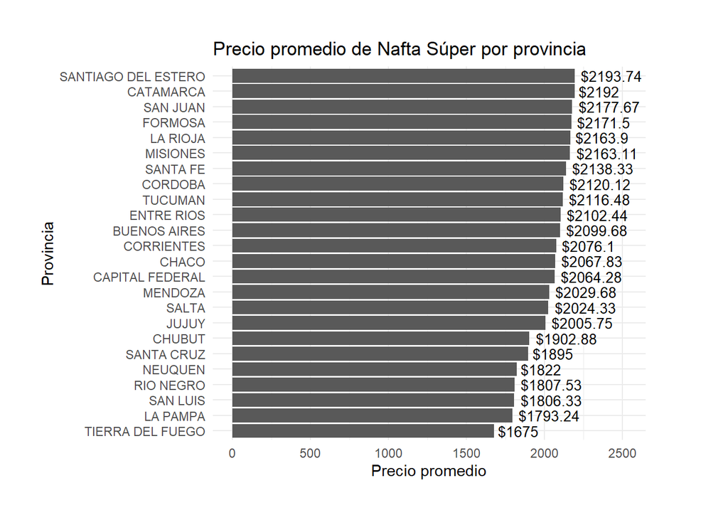

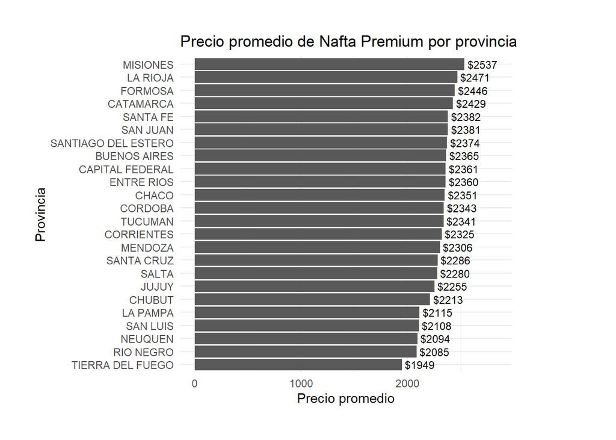

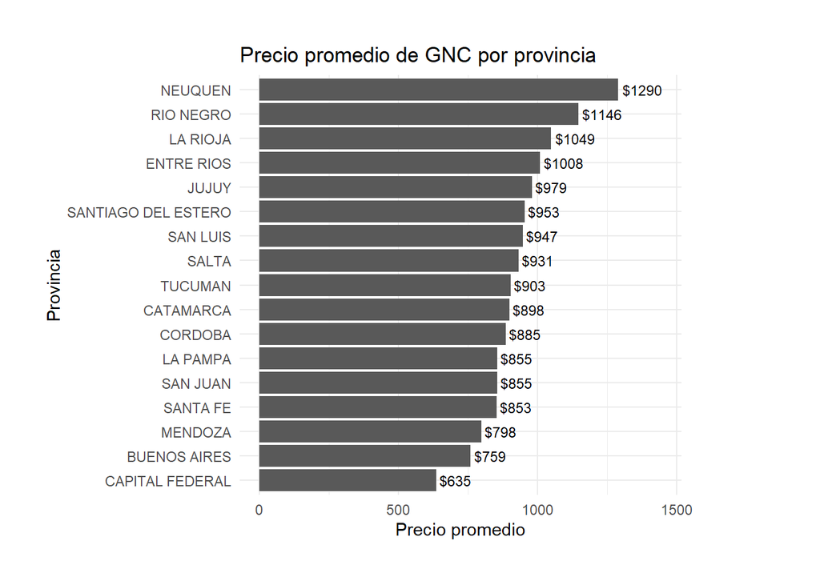

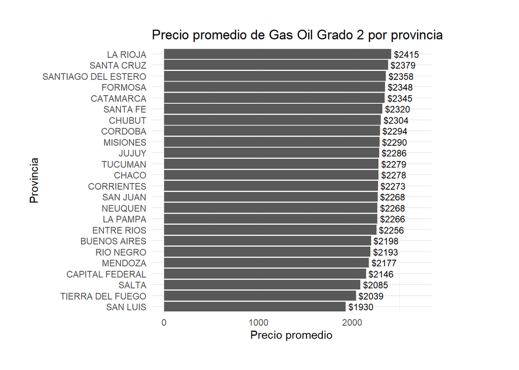

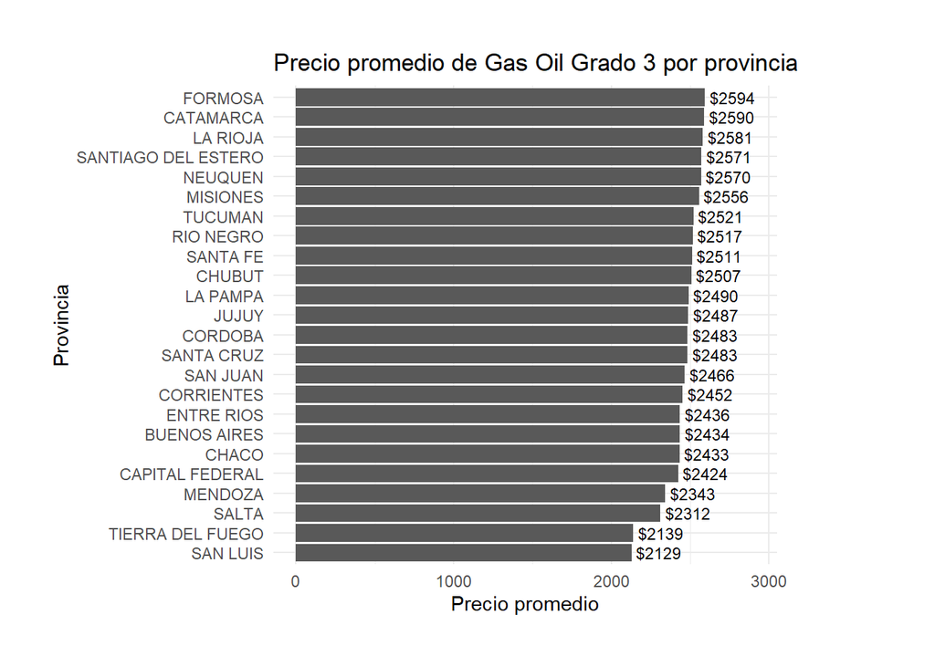

Finalmente un gráfico de promedio general de todos los combustibles

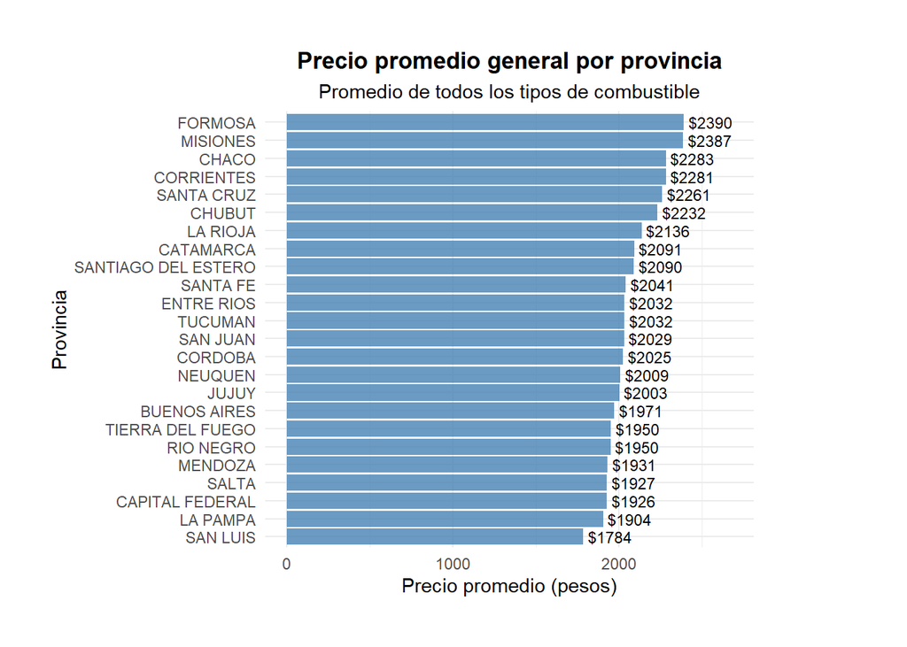

### 2. ¿Que tipo de combustible presenta la distribución de precios mas homogenea y cual la mas variable entre provincias?

Primero generaremos una tabla con medidas de dispersión

Medidas de homogeneidad por tipo de combustible

| Combustible | Media nacional | Mediana nacional | Desvío std | Rango | Mínimo | Máximo | CV | Asimetría | Curtosis | N provincias |
| --- | --- | --- | --- | --- | --- | --- | --- | --- | --- | --- |
| Gas Oil Grado 3 | 2486.33 | 2519.00 | 163.61 | 734 | 1944 | 2678 | 0.07 | -2.10 | 4.99 | 24 |
| Gas Oil Grado 2 | 2270.90 | 2336.50 | 151.85 | 724 | 1745 | 2469 | 0.07 | -2.09 | 5.54 | 24 |
| Nafta (premium) de más de 95 Ron | 2317.02 | 2398.75 | 168.71 | 622 | 1947 | 2569 | 0.07 | -1.03 | 0.13 | 24 |
| Nafta (súper) entre 92 y 95 Ron | 2040.17 | 2126.00 | 180.68 | 595 | 1623 | 2218 | 0.09 | -1.07 | -0.11 | 24 |
| GNC | 932.88 | 898.00 | 167.75 | 656 | 634 | 1290 | 0.18 | 0.80 | 1.28 | 17 |

Luego graficamos la desviación en Histogramas

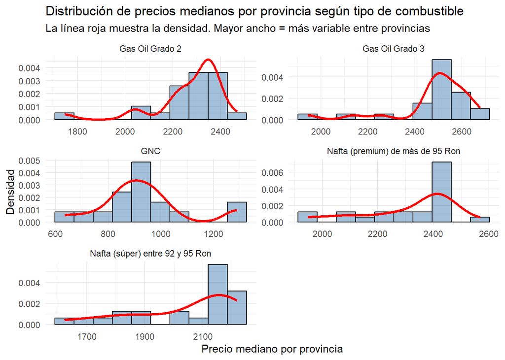

#### Observaciones preliminares:

- El coeficiente de variación nos permite ver que GNC es por lejos el mas variable con un 18% de CV, los mas homogeneos son por igual Nafta premium y los dos tipos de Gasoil con 7%.
- Respecto a asimetrías, Gasoil y Nafta presentan valores negativos, lo que significa que unas pocas provincias tienen precios significativamente mas baratos que el resto
- Respecto a Curtosis el Gasoil muestra valores elevados (4.99 y 5.54) demostrando altas concentraciones alrededor de valores concretos teniendo una tendencia Leptocúrtica, mientras tanto L nafta muestra valores mas cercanos a 0 asemejandose a distribuciones mesocurticas mas normales.

Estas Desviaciones existentes y prominentes en las 3 métricas observadas, nos dan una idea mas acabada de la heterogeneidad de precios a lo largo del país que desde lo hipotetico no se esperaba

### 3. ¿Existe relación entre el precio de la nafta super y la nafta premium? ¿Se mantiene la relación al rededor del 10-20% usual entre dichos combustibles?

Primero veremos que correlación existe entre ambos precios y un gráfico de dispersión de todas las provincias

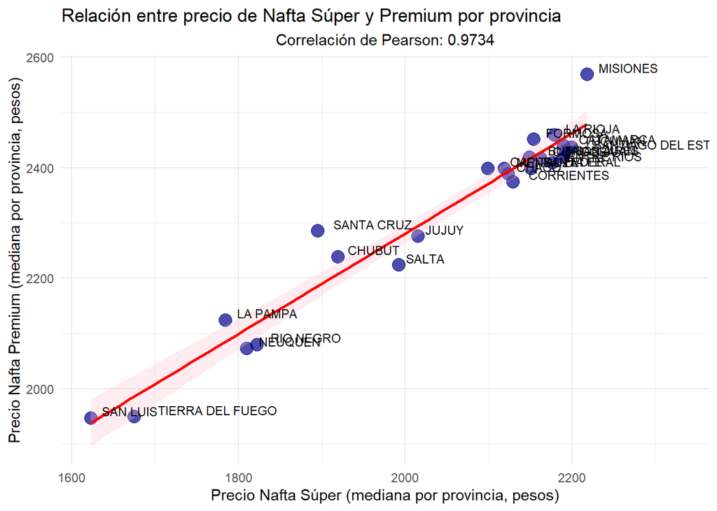

Ahora, un gráfico de barras que desglose los ratios de diferencias entre ambos productos por cada provincia

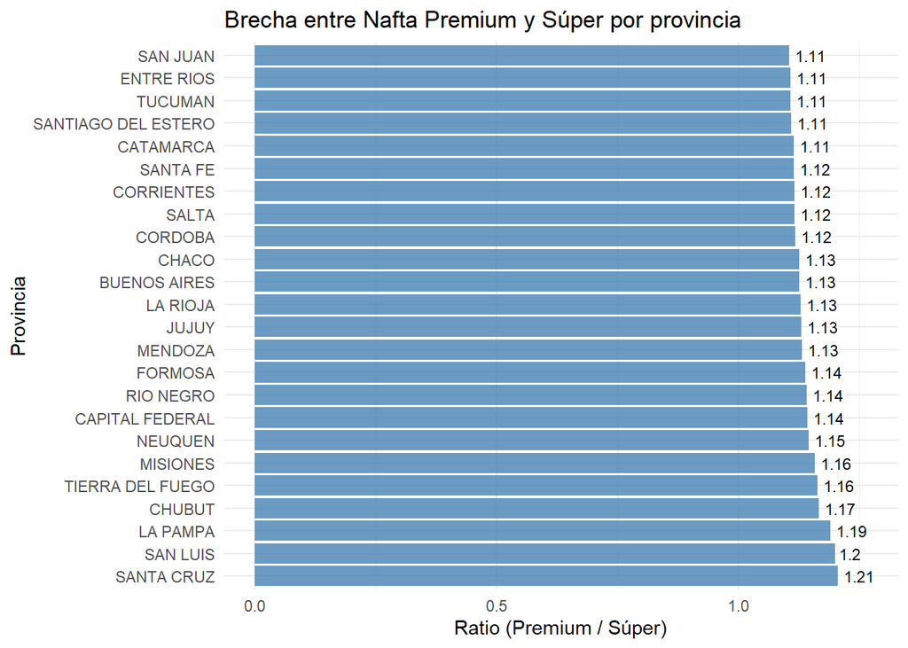

#### Observaciones preliminares:

A diferencia de las variaciones observadas geograficamente en los dos puntos anteriores, En este caso los datosmuestran una muy alta correlación de mas del 97%, una clara linea de tendencia normal en cuanto a la dispersión y unos ratios provinciales que van de 11 a 21% siguiendo casi perfectamente la pregunta inicial que buscaba diferencias de entre el 10 y 20%. Podemos concluir claramente que al menos en estas relaciones entre combustibles, el mercado no presenta distorsiones de precios.